# Part II - Factors that affect BorrowerRate

## by Sheriff Opeyemi Afolabi

## Investigation Overview

The main purpose of this investigation is to determine the factors that affect borrowers rate (that is BorrowerRate) and to understand the relationships between BorrowerRate and other numerical variables using data visualizations.

## Dataset Overview

My dataset contains 113,937 loans with 81 variables on eac loan, including loan amount, borrower rate (or interest rate), current loan status, borrower income, and many others. I will focus on 10 features or variables here.

## Distribution of BorrowerRate

The histplot below shows that BorrowerRate is not normally distributed but randomly skewed as the there are lots of peaks. Then mean is seen to be around 0.19 while the peak is around 0.15.

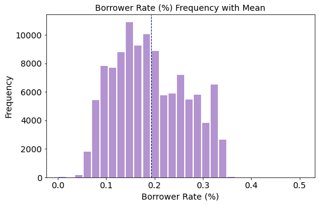

## Relationships between the Borrower Rate and other numeric variables

The correlation plot below shows a strong positive relationship between the following pairs of variables:

- BorrowerRate and BorrowerAPR: This means that increase in BorrowerRate will result to an increase in the BorrowerAPR and a decrease in BorrowerRate will bring about a decrease in BorrowerAPR.
- BorrowerRate and LenderYield: This means that increase in BorrowerRate will result to an increase in the LenderYield and a decrease in BorrowerRate will bring about a decrease in LenderYield.
- However, it can be seen that BorrowerRate has a strong negative relationship with ProsperRating (numeric): This means that the higher the ProsperRating (numeric), the lower the BorrowerRate.

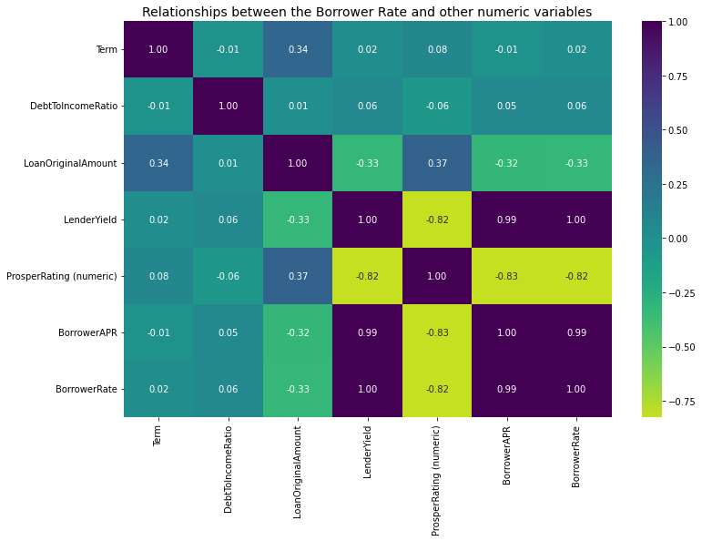

## Relationship between BorrowerRate and IsBorrowerHomeowner

The boxplot below clearly shows that borrowers who are home owners enjoy lower BorrowerRate compared to those who are not home owners.

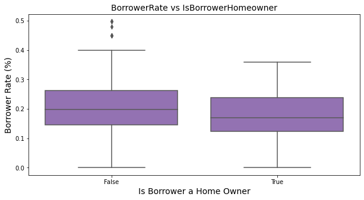